# Ptychodera Cisreg Development: Re-analysis of Purple Sea Urchin

Alberto Perez-Posada

4/22/2023

## About

In this markdown, we will do a re-analysis of the transcriptome of *Strongylocentrotus purpuratus* (Tu et al., 2013).

## Load libraries

```r
library(tidyverse)
library(stringr)
library(BiocGenerics)
library(EDASeq)
library(DESeq2)
library(tximport)
library(edgeR)
library(RUVSeq)
library(limma)
library(ComplexHeatmap)
library(circlize)
library(RColorBrewer)
```

## Load functions

```r
source("code/r_code/r_functions/sourcefolder.R")

sourceFolder(
  "code/r_code/r_functions",
  recursive = TRUE
  )

sourceFolder(
  "code/r_code/r_general",
  recursive = TRUE
  )
```

## Load data and Data preparation

Just like with Ptychodera, we run a preliminary DESeq2 design to retrieve the non-normalized count matrix

```r
samplesdir_RNA_spur <-
  "/home/ska/aperpos/Def_Pfla/other_spp/data_spur/spur_Tu/RNA/devstages/abundances/" # change path

sampleTable <-
  read.table(
    "/home/ska/aperpos/Def_Pfla/other_spp/data_spur/spur_Tu/RNA/devstages/abundances/sample_table.tsv", #change path
    header=F)[,c(1,1,2,3)]

colnames(sampleTable) <-
  c("name","dir","condition","batch")

sampleTable$batch <- factor(sampleTable$batch)
numsamples_RNA_spur <- nrow(sampleTable)
```

We will also load a dictionary between the gene ids of our mapping and the gene ids of the proteome used in comparative analyses (OMA, Orthofinder). This will be useful later in the future.

```r
sp_strpu <- read.table("outputs/comparative/oma/dicts/STRPU.dct", col.names = c("key","value"))
```

We use tximport to load the actual count files based on the sample table:

```r
files <-
  list.files(samplesdir_RNA_spur, "h5",recursive = T, full.names = T)

names(files) <-
  list.dirs(samplesdir_RNA_spur,full.names = F)[-1]

txi.kallisto <-
  tximport(files, type = "kallisto", txOut = TRUE)
```

```
## 1 2 3 4 5 6 7 8 9 10 11 12 13 14 15 16 17
```

And we create a deseq2 object that we can subset later to retrieve the counts.

```r
dds_txi <-
  DESeqDataSetFromTximport(
    txi.kallisto,
    colData = sampleTable,
    design = ~ batch + condition
    )
```

```
## using counts and average transcript lengths from tximport
```

```r
dds_txi$condition <-
  relevel(dds_txi$condition, ref = c("00_Uf_0hpf"))
```

We retrieve the counts from this object and apply a filter to keep genes with more than 5 counts in at least two stages.

```r
spur_raw <- counts(dds_txi,normalized=FALSE)

filter <- apply(spur_raw, 1, function(x) length(x[x>5])>=2)

spur_raw_filt <- spur_raw[filter,]

condition_x <- as.factor(substr(sampleTable$condition,1,5))
```

We create an expression set object for edgeR:

```r
spur_set <-
  newSeqExpressionSet(
    as.matrix(spur_raw_filt),
    phenoData =
      data.frame(
        condition_x,
        row.names=colnames(spur_raw_filt)
        )
    )

spur_set
```

```
## SeqExpressionSet (storageMode: lockedEnvironment)
## assayData: 24406 features, 17 samples
##   element names: counts, normalizedCounts, offset
## protocolData: none
## phenoData
##   sampleNames: 00_Uf_0hpf 01_Cleavage_10hpf ... 15_Young_juvenile (17
##     total)
##   varLabels: condition_x
##   varMetadata: labelDescription
## featureData: none
## experimentData: use 'experimentData(object)'
## Annotation:
```

We have here a look at the data:

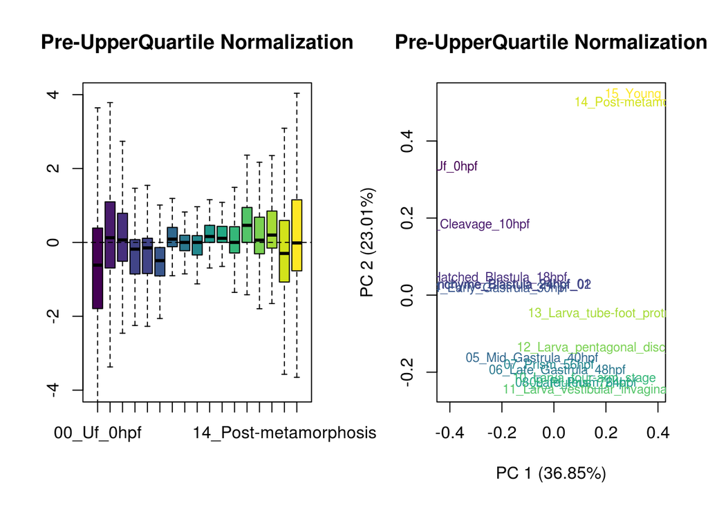

```r
colors <- viridis(length(levels(condition_x)))

par(mfrow = c(1,2))
plotRLE(spur_set, outline=FALSE, ylim=c(-4, 4), col=colors[condition_x],cex.lab=0.5,main="Pre-UpperQuartile Normalization")
plotPCA(spur_set, col=colors[condition_x], cex=0.75,main="Pre-UpperQuartile Normalization")
```

```r
par(mfrow = c(1,1))
```

We do Upper Quantile Normalisation just like we did with Ptychodera to transform the data aiming for equal variance across stage samples:

```r
spur_set <- betweenLaneNormalization(spur_set, which="upper")
```

And we check now:

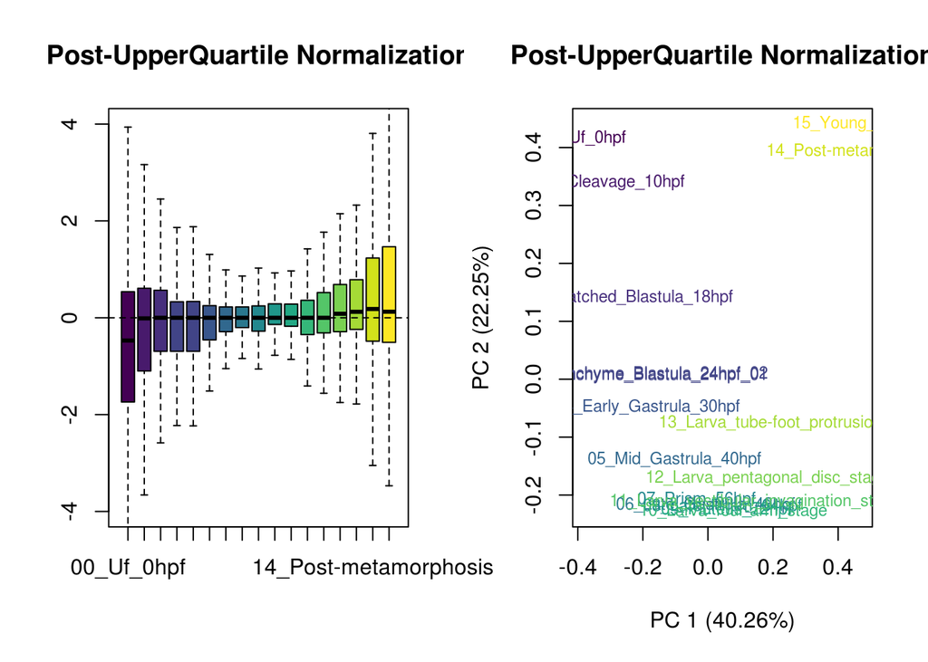

```r
par(mfrow = c(1,2))
plotRLE(spur_set, outline=FALSE, ylim=c(-4, 4), col=colors[condition_x],main="Post-UpperQuartile Normalization")
plotPCA(spur_set, col=colors[condition_x], cex=0.75,main="Post-UpperQuartile Normalization")
```

```r
par(mfrow = c(1,1))
```

We run edgeR a first time to run in silico empirical genes that do not change. We first create a model matrix just accounting for the developmental stage. After that we calculate normalised factors, estimate GLM common and tag-wise dispersion, and do the fitting.

And after that we apply the likelihood ratio test, and get the last genes after the top 20K as “invariant”:

```r
spur_design <- model.matrix(~condition_x, data=pData(spur_set))

# DGE list
spur_y <- DGEList(counts=counts(spur_set), group=condition_x)

# Calculating NormFactors
spur_y <- calcNormFactors(spur_y, method="upperquartile")
spur_y <- estimateGLMCommonDisp(spur_y, spur_design)
spur_y <- estimateGLMTagwiseDisp(spur_y, spur_design)

# glmFit and Likelihood Ratio Test
spur_fit <- glmFit(spur_y, spur_design)
spur_lrt <- glmLRT(spur_fit, coef=2)

# Get the top results and keep the OTHERS
top <- topTags(spur_lrt, n=nrow(spur_set))$table
empirical <- rownames(spur_set)[which(!(rownames(spur_set) %in% rownames(top)[1:20000]))]
```

After this we run RUVseq using those “in-silico invariable genes”.

```r
spur_set2 <- RUVg(spur_set, empirical, k=1)
pData(spur_set2)
```

```
##                                        condition_x         W_1
## 00_Uf_0hpf                                   00_Uf -0.30034247
## 01_Cleavage_10hpf                            01_Cl -0.29985113
## 02_Hatched_Blastula_18hpf                    02_Ha -0.21703342
## 03_Mesenchyme_Blastula_24hpf_01              03_Me -0.20630749
## 03_Mesenchyme_Blastula_24hpf_02              03_Me -0.20561225
## 04_Early_Gastrula_30hpf                      04_Ea -0.18431907
## 05_Mid_Gastrula_40hpf                        05_Mi -0.11417987
## 06_Late_Gastrula_48hpf                       06_La -0.03736630
## 07_Prism_56hpf                               07_Pr -0.05569798
## 08_Late_Prism_64hpf                          08_La  0.01737980
## 09_Pluteus_72hpf                             09_Pl  0.02705540
## 10_Larva_four-arm_stage                      10_La  0.03267347
## 11_Larva_vestibular_invagination_stage       11_La  0.09938702
## 12_Larva_pentagonal_disc_stage               12_La  0.14835800
## 13_Larva_tube-foot_protrusion_stage          13_La  0.26374317
## 14_Post-metamorphosis                        14_Po  0.50480379
## 15_Young_juvenile                            15_Yo  0.52730934
```

We have a look at the looks of these genes after RUV-seq

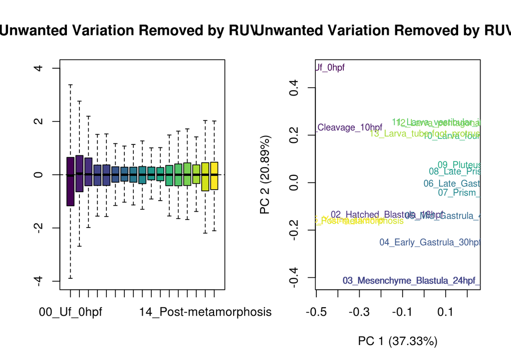

```r
par(mfrow = c(1,2))
plotRLE(spur_set2, outline=FALSE, ylim=c(-4, 4), col=colors[condition_x],main="Unwanted Variation Removed by RUVSeq")
plotPCA(spur_set2, col=colors[condition_x], cex=0.75,main="Unwanted Variation Removed by RUVSeq")
```

```r
par(mfrow = c(1,1))
```

And here the final dataset after all these transformations:

```r
spur_vsd <- as.data.frame(counts(spur_set2))

colnames(spur_vsd) <-
  c(
    "00_Uf_0h", "01_Cle_10h", "02_HaBl_18h", "03_MeBl_24h1", "03_MeBl_24h2",
    "04_EG_30h", "05_MG_40h", "06_LG_48h", "07_Pri_56h",
    "08_LPr_64h", "09_Plu_72h", "10_4arm", "11_VesInv",
    "12_PentDis", "13_TubFootPr", "14_Post_Met", "15_YoungJuv"
  )
```

## GLM fitting using edgeR to get stage-specific genes

Since DESeq2 cannot be used because we dont have replicates, we can try some of the options by edgeR. We will now do linear model fitting using the variance-stabilised data we got from RUV-Seq.

```r
spur_y1 <- DGEList(counts(spur_set2),group=condition_x)
spur_y1$samples$group <- 1
```

Then estimate the common dispersion from the housekeeping genes and all the libraries as one group:

```r
spur_y0 <- estimateDisp(spur_y1[empirical,], trend="none", tagwise=FALSE)
```

```
## Using classic mode.
```

Then insert this into the full data object and proceed:

```r
spur_y1$common.dispersion <- spur_y0$common.dispersion
spur_fit <- glmFit(spur_y1, spur_design)
spur_lrt <- glmLRT(spur_fit)
```

and so on. A reasonably large number of control transcripts is required, at least a few dozen and ideally hundreds.

```r
spur_top <- topTags(spur_lrt, n=nrow(spur_set))$table
spur_top_dev <- spur_vsd[rownames(spur_vsd) %in% rownames(spur_top[spur_top$PValue < 0.2,]),]

colnames(spur_top_dev) <-
  c(
    "00_Uf_0h", "01_Cle_10h", "02_HaBl_18h", "03_MeBl_24h1", "03_MeBl_24h2",
    "04_EG_30h", "05_MG_40h", "06_LG_48h", "07_Pri_56h",
    "08_LPr_64h", "09_Plu_72h", "10_4arm", "11_VesInv",
    "12_PentDis", "13_TubFootPr", "14_Post_Met", "15_YoungJuv"
  )
```

And the total number of genes identified, nearly 9K:

```r
nrow(spur_top_dev)
```

```
## [1] 8871
```

From this we visualise the dataset.

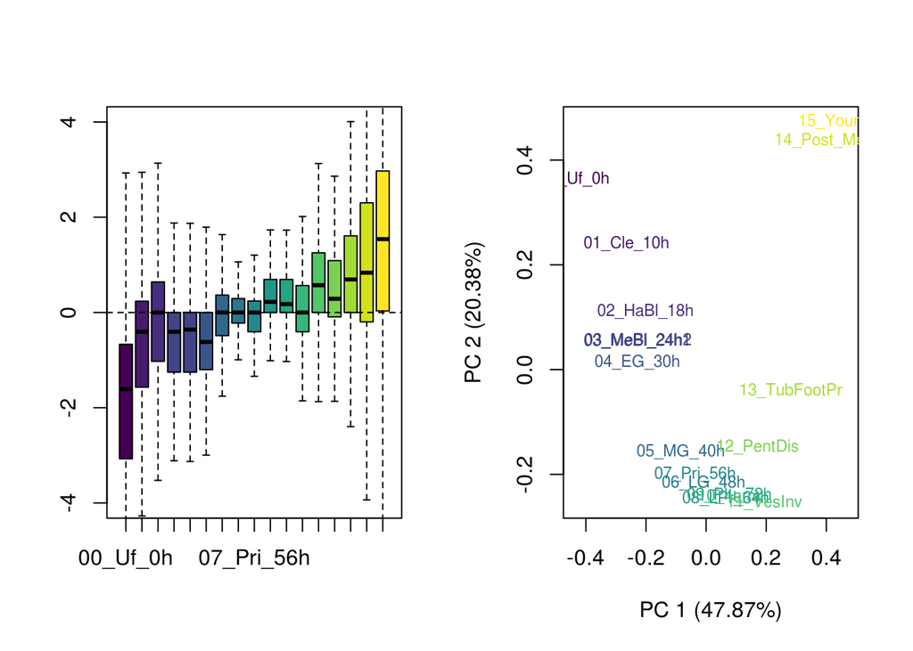

```r
par(mfrow = c(1,2))
plotRLE(as.matrix(spur_top_dev), outline=FALSE, ylim=c(-4, 4), col=colors[condition_x])
plotPCA(as.matrix(spur_top_dev),col=colors[condition_x], cex=0.75)
```

```r
par(mfrow = c(1,1))
```

## Transcriptome correlations

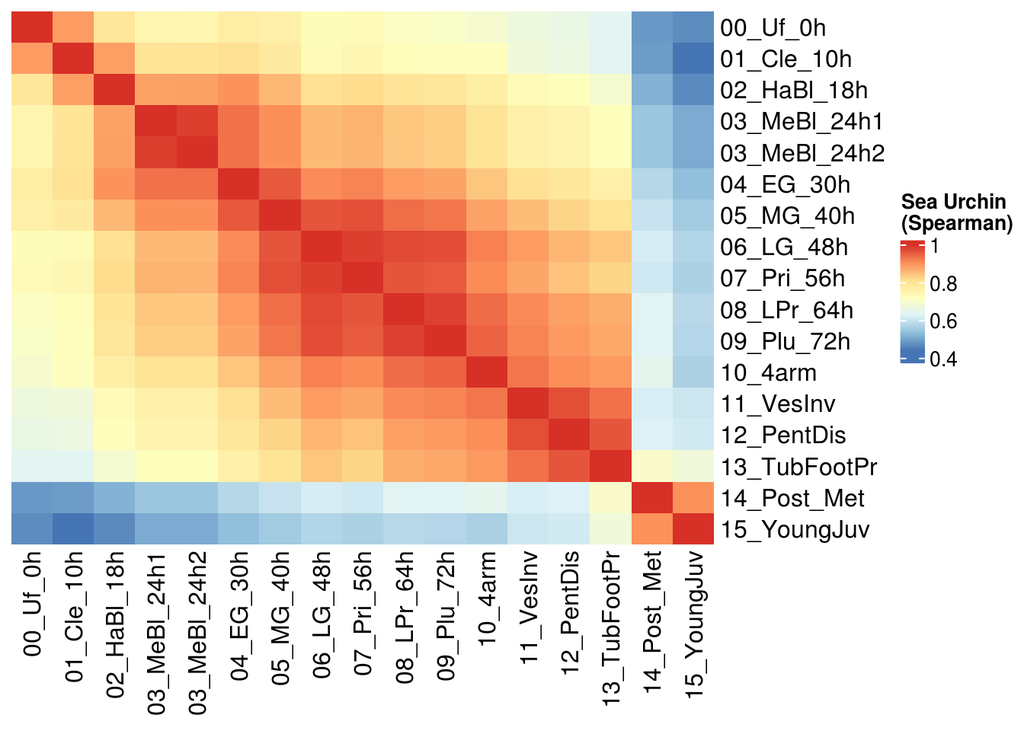

```r
spur_cor <- cor(spur_vsd, method = "sp")

Heatmap(
  spur_cor,
  name = "Sea Urchin\n(Spearman)",
  cluster_rows = F,
  cluster_columns = F,
  col=colorRampPalette(rev(brewer.pal(7,"RdYlBu")))(100)
  )
```

## Clustering using hierarchical clustering

We will group the stage-specific expressed genes in groups of stage-specific coexpression using hierarchical clustering. We proceed to do clustering as we did previously for the other species.

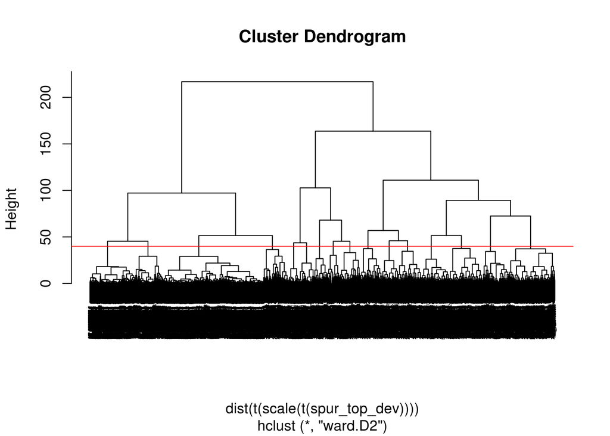

```r
spur_hc <-
  hclust( # clustering ward.D2
    dist( # using default distance metric
      t(scale(t( # using the centered-around-mean scaling
        spur_top_dev # of the top stage-specific genes
        )))
      ),
    method = "ward.D2"
    )
plot(spur_hc,cex=0.3)
abline(40,0,col="red")
```

```r
RNA_spur <-
  data.frame(
    spur_top_dev,
    clusterID = cutree(spur_hc, h=30)
  )
unique(RNA_spur$clusterID)
```

```
##  [1]  1  2  3  4  5  6  7  8  9 10 11 12 13 14 15 16 17 18 19 20 21 22 23 24 25
```

Based on visual inspection, we assign new cluster names to give them new ordering:

```r
spur_newcl <-
  read.table(
    file = "outputs/comparative/reanalysis/spur/spur_newcl.tsv",
    header = FALSE,
    col.names = c("clusterID","newcl")
  )

RNA_spur$newcl <-
  translate_ids(
    x = RNA_spur$clusterID,
    dict = spur_newcl
  )

#We do not need the original hierachical cluster ids anymore
RNA_spur$clusterID <- NULL
```

And a final Heatmap for visualisation:

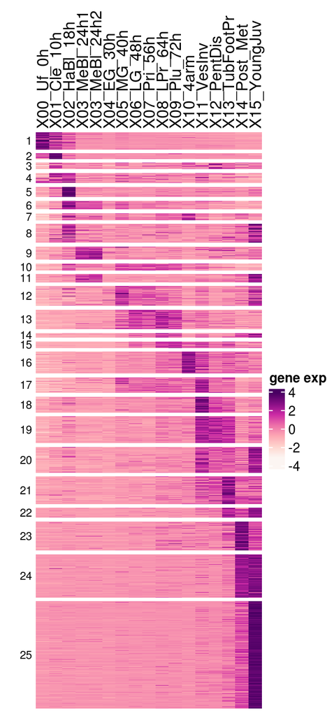

```r
set.seed(1234)
rna_spur_viz <- RNA_spur[sample(nrow(RNA_spur),1000),]
spur_heat <- Heatmap(
  t(scale(t(rna_spur_viz[,1:17]))),
  name = "gene exp",
  row_split=rna_spur_viz$newcl,
  show_row_names = F,
  cluster_rows=F,
  cluster_columns=F,
  row_title = NULL,
  left_annotation =
  rowAnnotation(
    cluster =
      anno_block(
        gp = gpar(col=NA,fill=NA),
        labels = unique(sort(rna_spur_viz$newcl)),
        labels_gp = gpar(col = "black", cex=0.7),
        labels_just = "right",
        labels_offset = unit(1, "npc"),
        labels_rot=0
        )
    ),
  column_names_side="top",
  col = colorRampPalette(rev(sequential_hcl(7,"RdPu")))(100)
)

draw(spur_heat)
```

And the average expression profile of the different clusters of stage-specific genes:

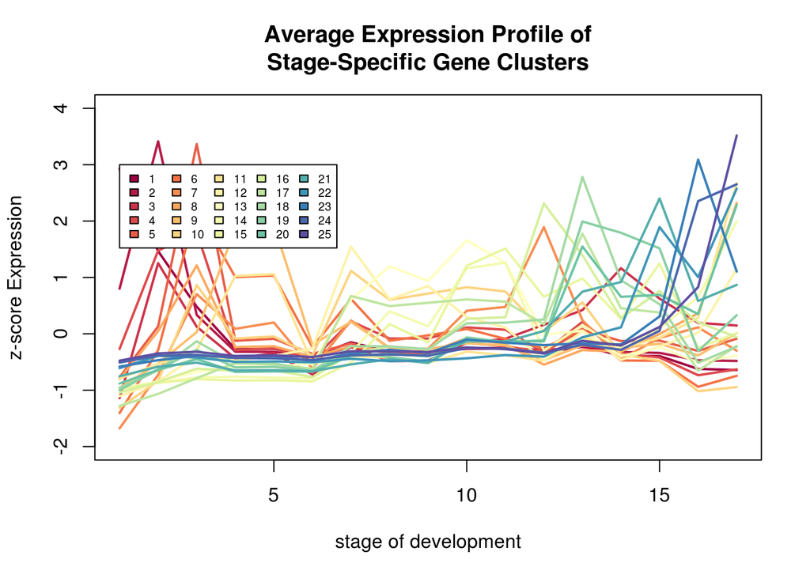

```r
spur_cl_avgs <-
  aggregate(
    t(scale(t(RNA_spur[, 1:17]))),
    by = list(cluster = RNA_spur$newcl),
    FUN = mean
  )[, -1]

spur_cl_colors <-
  colorRampPalette(colors=brewer.pal(11,"Spectral"))(nrow(spur_cl_avgs))

plot(
  0,
  xlim = c(1, 17),
  ylim = c(-2, 4),
  type = "n",
  main = "Average Expression Profile of\nStage-Specific Gene Clusters",
  xlab = "stage of development",
  ylab = "z-score Expression"
)
for (i in 1:nrow(spur_cl_avgs)) {
  lines(c(1:17),
        spur_cl_avgs[i,],
        type = "l",
        col = spur_cl_colors[i],
        lwd = 2
  )
}
legend(
  x = 1,
  y = 3,
  legend = rownames(spur_cl_avgs),
  fill = spur_cl_colors,
  ncol = 5,
  cex = 0.6
)
```

## Save the data

We finally translate the gene ids to the same ones used in OMA:

```r
rownames(spur_vsd) <- translate_ids(x = rownames(spur_vsd), dict = sp_strpu, return.missing = TRUE)
rownames(spur_top_dev) <- translate_ids(x = rownames(spur_top_dev), dict = sp_strpu, return.missing = TRUE)
rownames(RNA_spur) <- translate_ids(x = rownames(RNA_spur), dict = sp_strpu, return.missing = TRUE)
```

And we create a table of gene <-> cluster for later use in our comparative analyses:

```r
spur_cl <-
  data.frame(
    id = rownames(RNA_spur),
    cID = RNA_spur$newcl
  )
```

And we save the data for TF analysis and for pairwise comparisons:

```r
save(
  spur_vsd,
  spur_top_dev,
  RNA_spur,
  spur_cl_avgs,
  spur_cl,
  file = "outputs/rda/spur_reanalysis.rda"
)
```